# Project

Sukhbir Singh

2024-05-08

The Wind River Experimental Forest is a field site about 40 miles NE of Vancouver, WA in the Gifford Pinchot National Forest. This is in Neon’s Pacific Northwest Domain (D16). The area is populated by douglas firs and western hemlocks of diverse ages. The region’s climate is temperate with an average temperature of 9.2°C and average precipitation of 87.6 in. In the valley of volcanoes, Mt. Rainier and Mt. St. Helens, the soil here is comprised of volcanic ashe, pumice, basalt bedrock, and andesite (leftover from lava flows). Among the animals living in this area are elk, bobcats, cougars, black bears, various birds, and many small mammals. After being used as a seedling nursery for post-wildfire forest rehabilitation for almost a century, the NEON site was established in 2006 and sampling for the project began in 2018.

## An Overview of Acidobacteriota

Acidobacteriota are a diverse phylum of bacteria that can be found in many different habitats, such as soil, oceans, caves, and hot springs. Most members of this phylum are acidophilic. Despite how common they are, not much is known about acidobacteria, as they are difficult to grow in culture. Acidobacteria are believed to play several ecological roles, such as plant-growth promoting rhizobacteria, decomposers, especially of complex carbohydrates, as well as sulfur metabolism. They are also considered keystone taxa, which are taxa that are important for the stability of the ecosystem in grasslands, forests, and agricultural soils. [@kalam_recent_2020]

## Motivating Reasons

The motivating reasons behind this project were to further develop my skills in R Posit Cloud, to practice integration and manipulation of data, and to learn about acidobacteriota and the WREF site. I took Biology 478: Human Genome Analysis in the fall of 2023 and this gave me some foundational skills for working with data in R. Through my engagement with this project, I have learned more about data wrangling, ggplot, ggtrees, quatro website building, and github repositories. These will be very useful to my future career in biological research as I will be able to analyze and present data that I have collected myself for presentations and papers. The topic of this project, acidobacteriota and WREF, have given me insight into a particular bacterial phylum and its evolutionary lineage. It also shed light onto how data collection sites are chosen, managed, and utilized.

## Methods

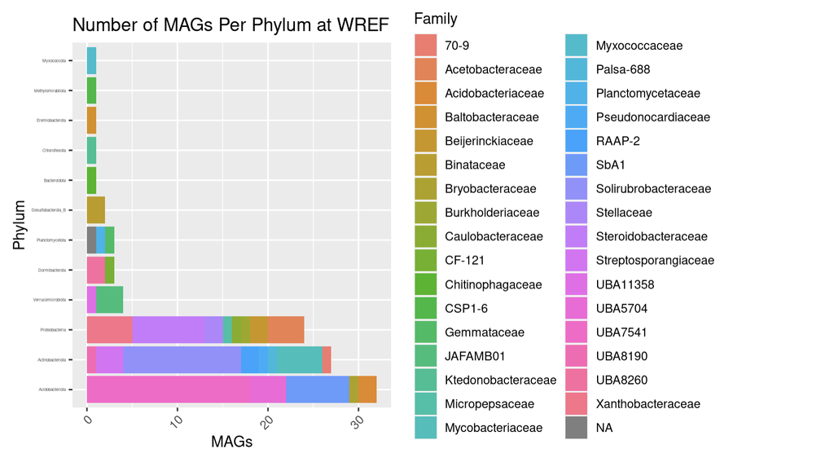

Figure 1

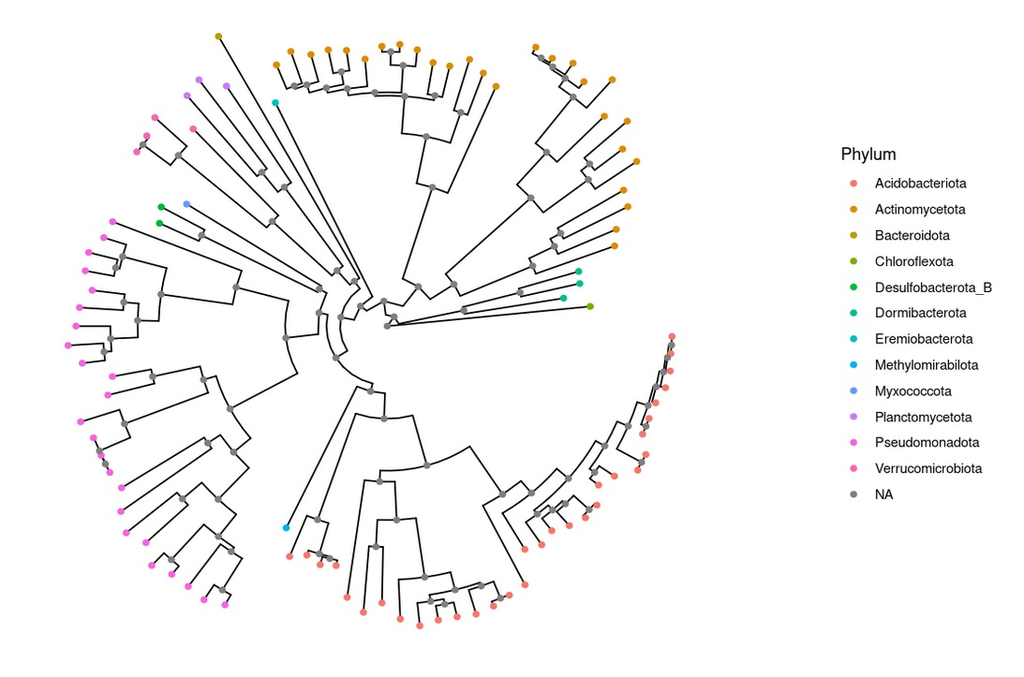

Figure 2

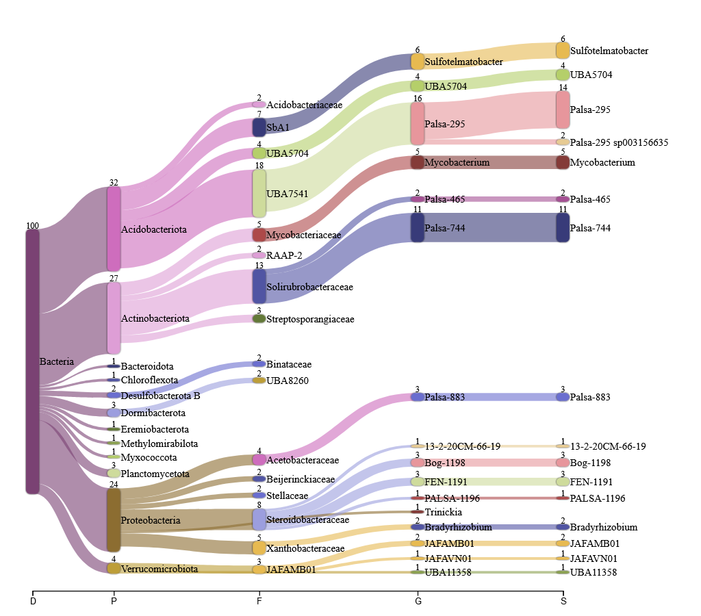

Figure 3

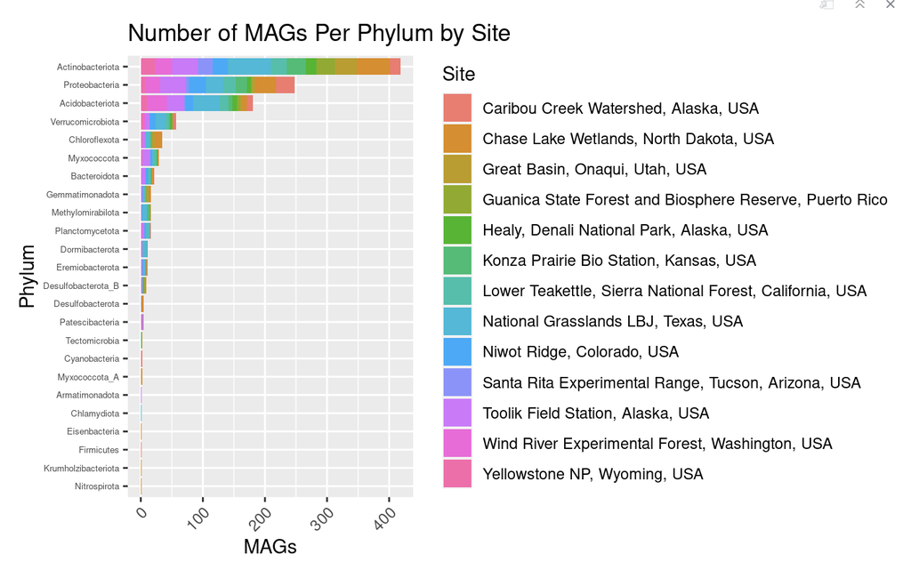

Figure 4

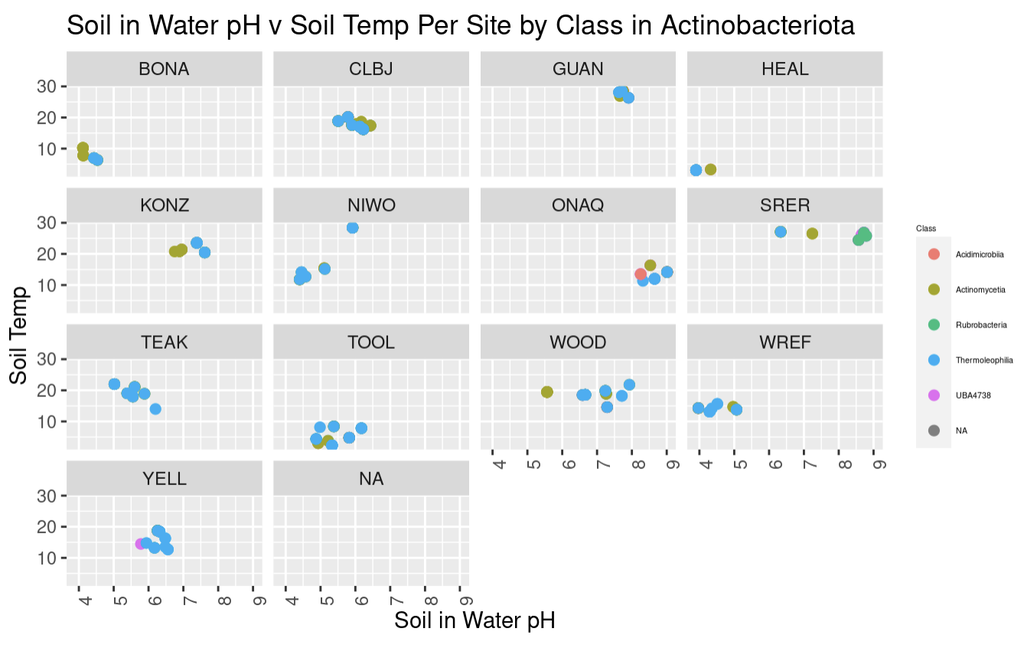

Figure 5

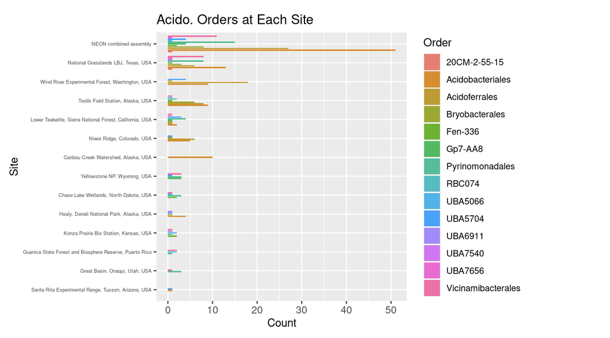

Figure 6

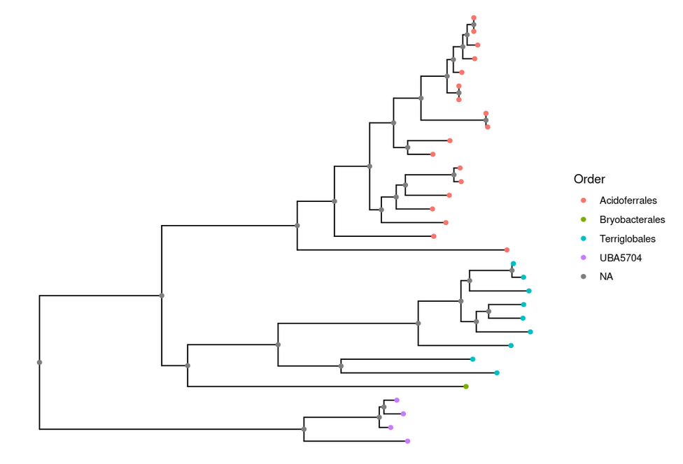

Figure 7 Phacido by order

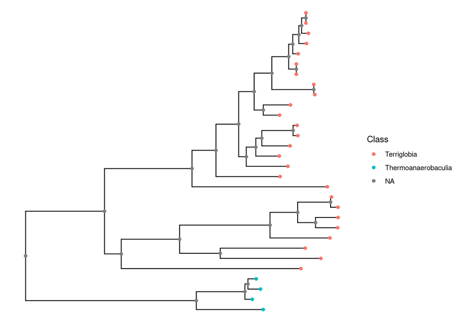

Figure 8 phacido by class

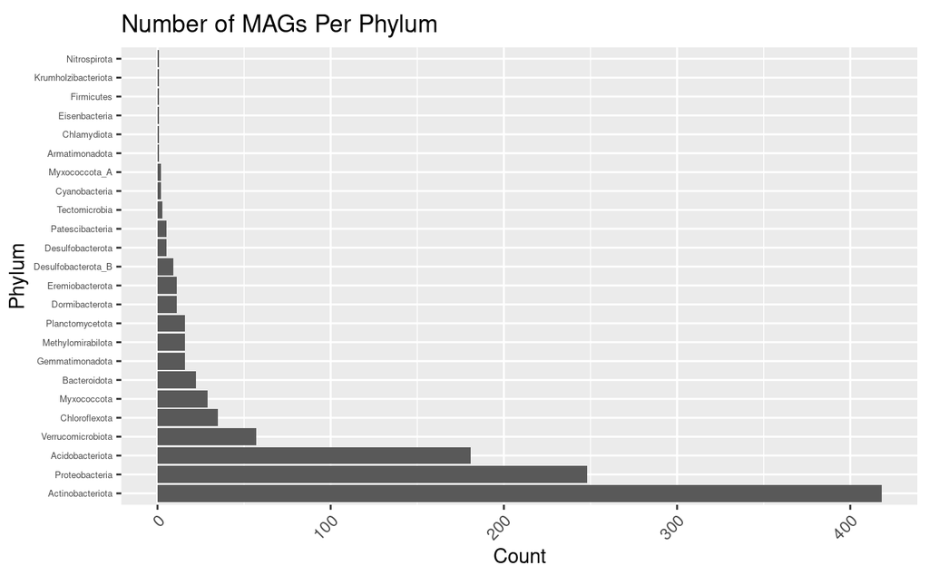

Figure 9 Number of MAGs per phylum

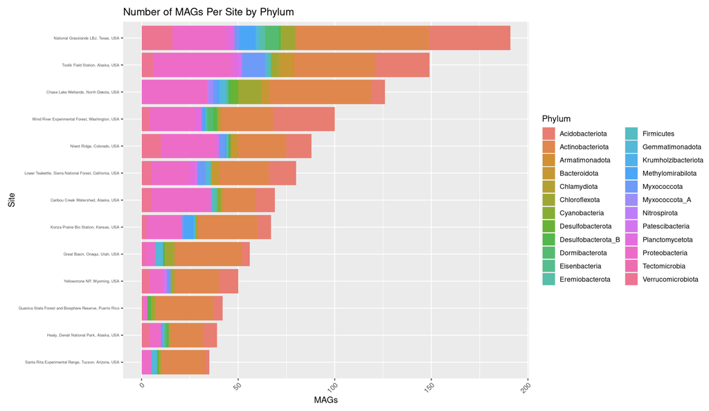

Figure 10 number of MAGs per site by phylum

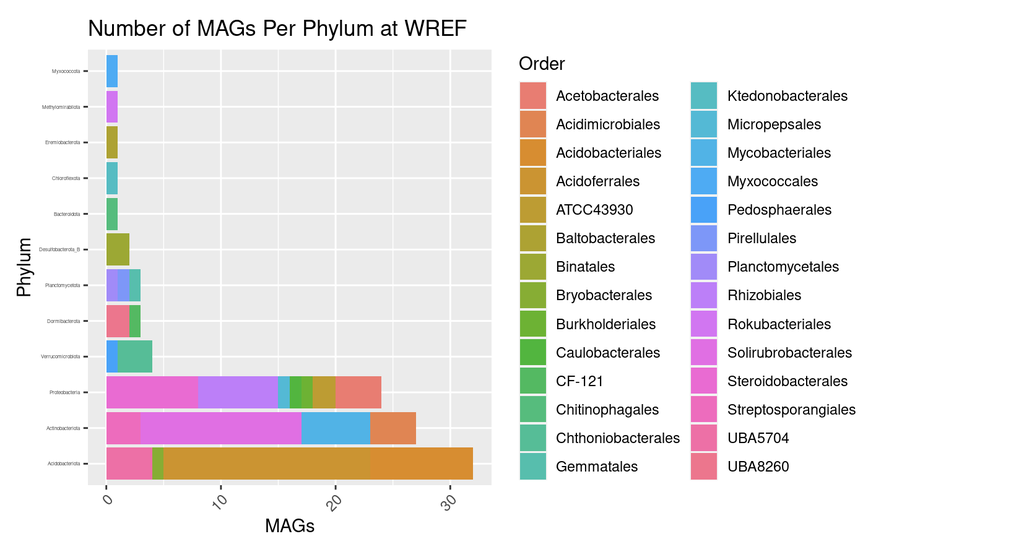

Figure 11 WREF number of MAGs per phylum by order

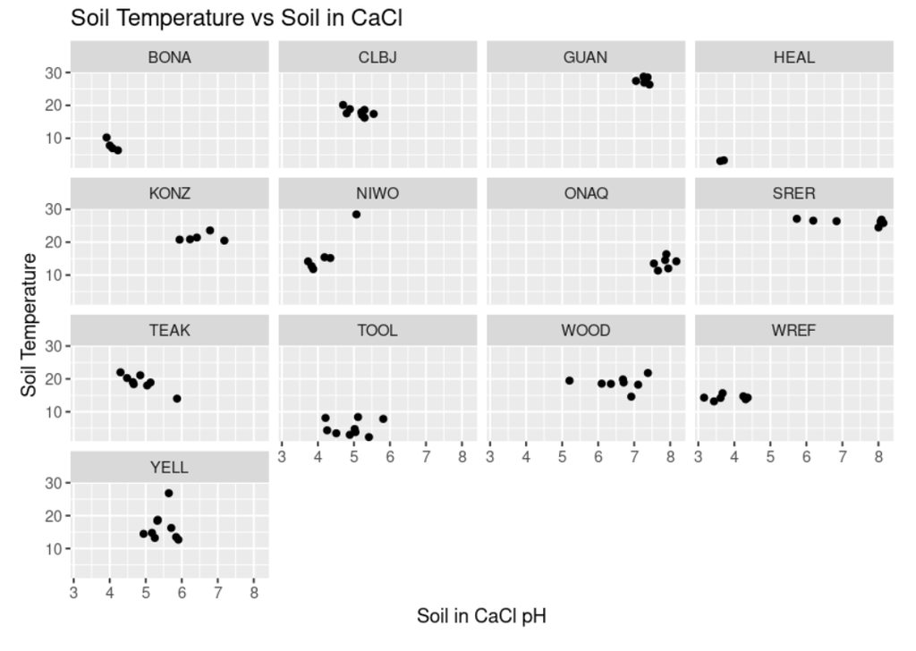

Figure 12 Soil temp vs Soial in CaCl

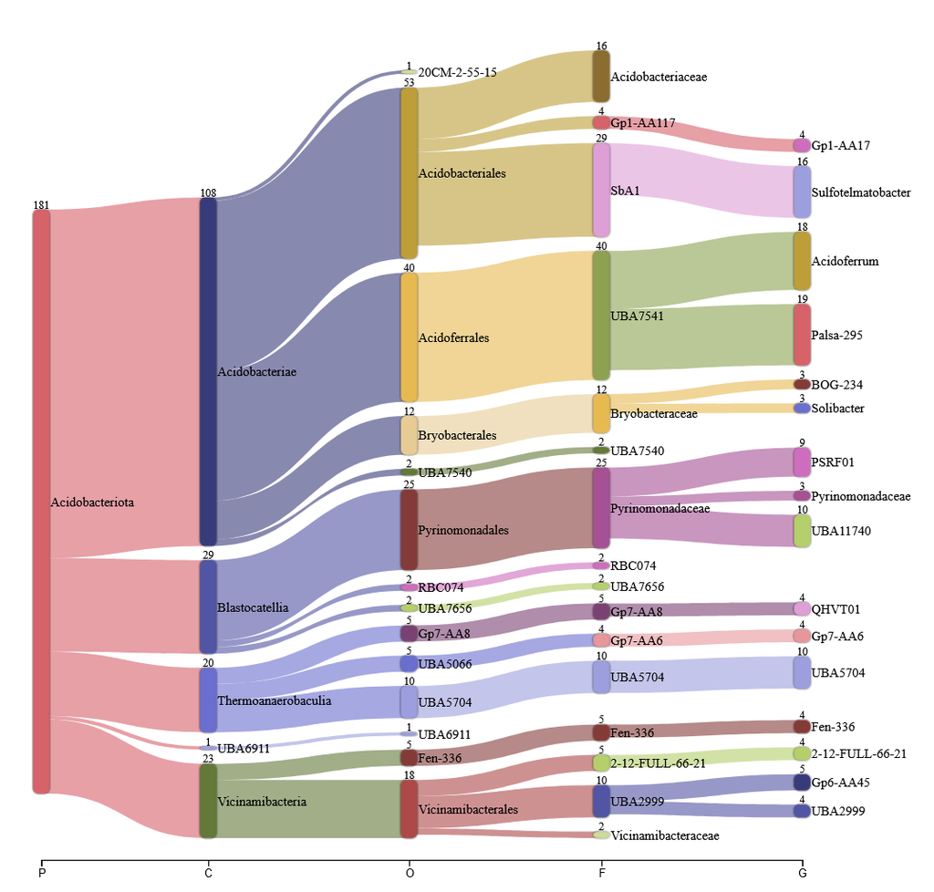

Figure 13

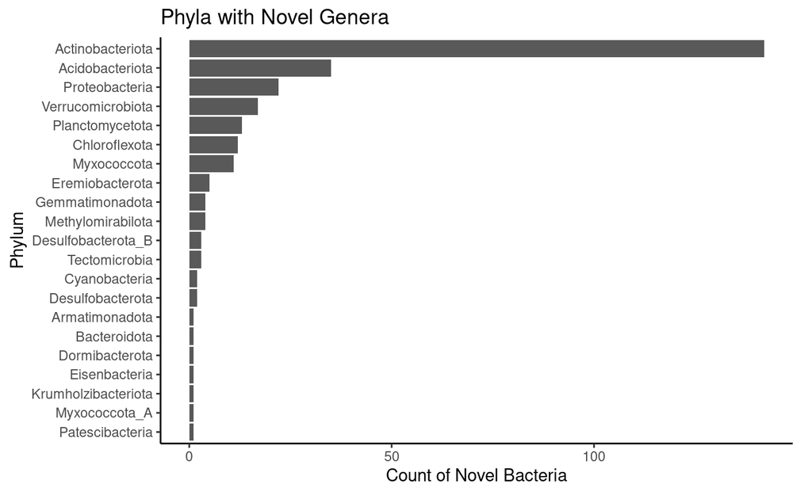

Figure 14 Phyla with Noevel Genera